# Canaleta Verde (Vegetated Swale)

Dimensionamento, Construção e Monitoramento  
Bioengenharia de Solos

Luiz Diego Vidal Santos

## Visão Geral da Aula

### Tópicos

- 1 O que é uma canaleta verde?
- 2 Princípios hidráulicos e sedimentológicos
- 3 Seções transversais e materiais
- 4 Dimensionamento hidráulico (Manning)
- 5 Projeto e implantação em campo
- 6 Combinação com hidrossemeadura e biomanta
- 7 Monitoramento e manutenção
- 8 Síntese e atividade

**Objetivo da Aula**

Compreender o conceito de **canaleta verde** (*vegetated swale / bioswale*) como sistema de drenagem vegetada para **condução controlada de escoamento superficial**, dominar o **dimensionamento hidráulico** pela equação de Manning, os critérios de **implantação** e os protocolos de **monitoramento** para garantir a eficiência na dissipação de energia e infiltração.

# 1. O QUE É UMA CANALETA VERDE?

## Definição e contexto

### Conceito

A **canaleta verde** (*vegetated swale*, *bioswale* ou *grassed waterway*) é um **canal de drenagem raso e largo**, escavado no terreno ou conformado sobre a superfície, cujo leito e taludes são **integralmente revestidos com vegetação viva** (gramíneas, leguminosas, ou combinações) e, frequentemente, protegidos por **biomanta antierosiva** na fase de estabelecimento.

Trata-se de uma infraestrutura verde (*green infrastructure*) que desempenha simultaneamente as funções de:

- **Condução** do escoamento pluvial com velocidade controlada
- **Dissipação de energia** pela rugosidade hidráulica da vegetação
- **Infiltração** da água no perfil do solo ao longo do percurso
- **Filtração** de sedimentos e poluentes difusos por deposição gravitacional e adsorção radicular
- **Estabilização do solo** pelo sistema radicular das plantas

A canaleta verde é uma técnica de **bioengenharia de solos** que substitui os canais revestidos de concreto convencionais, utilizando a vegetação como elemento estrutural de proteção contra erosão e como promotora da recarga hídrica subterrânea.

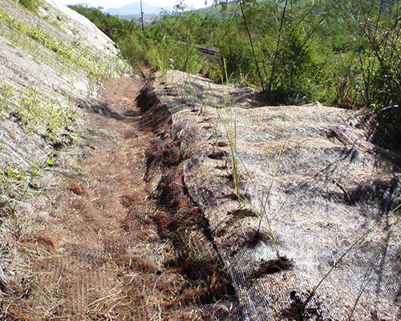

## Canaleta verde vs. canal convencional

### Comparação funcional

| Aspecto | Canal Convencional | Canaleta Verde |
| --- | --- | --- |
| Revestimento | Concreto, gabião, pedra | Vegetação viva + biomanta |
| Infiltração | Nula (impermeável) | Alta (permeável) |
| Rugosidade ($n$) | 0,012–0,015 | 0,030–0,150 |
| Velocidade de fluxo | Alta (rápida) | Baixa (controlada) |
| Custo de implantação | Alto | Baixo a moderado |
| Manutenção | Baixa | Periódica (poda, replantio) |
| Impacto ambiental | Elevado | Reduzido |
| Vida útil | > 30 anos | Permanente (com manejo) |
| Qualidade da água | Sem melhoria | Filtra sedimentos e poluentes |
| Recarga de aquífero | Não contribui | Contribui significativamente |

### Quando utilizar a canaleta verde?

**Indicações principais**

- Saída de terraços em gradiente (canal escoadouro vegetado)
- Drenagem de taludes rodoviários e ferroviários
- Descarga de sistemas de captação de águas pluviais
- Controle de escoamento em áreas mineradas
- Drenagem de áreas agrícolas e pastagens
- Sistemas de drenagem sustentável (SuDS) urbanos

A rugosidade da vegetação ($n = 0{,}030$ a $0{,}150$) é até **10 vezes maior** que a do concreto ($n = 0{,}012$), o que reduz a velocidade do fluxo e a tensão cisalhante no leito, protegendo o solo contra incisão.

## Tipologia das canaletas vegetadas

### Classificação por geometria

**Seção trapezoidal** é a mais utilizada em bioengenharia, por oferecer estabilidade geotécnica dos taludes e facilidade de mecanização. Já a **seção parabólica** aproxima a forma dos canais naturais e é recomendada para ambientes com restrição paisagística. A **seção triangular** (valeta em V) aplica-se apenas a taludes rodoviários com pequenas vazões.

```
flowchart TD
    A["Canaleta Verde"] --> B["Trapezoidal"]
    A --> C["Parabólica"]
    A --> D["Triangular (V)"]
    B --> E["Maior capacidade<br>Taludes estáveis<br>Mais comum"]
    C --> F["Forma natural<br>Paisagismo<br>Auto-conformação"]
    D --> G["Pequenas vazões<br>Rodovias<br>Menor seção"]
    style A fill:#2E7D32,color:#fff
    style B fill:#2135A6,color:#fff
    style C fill:#2135A6,color:#fff
    style D fill:#2135A6,color:#fff
```

### Classificação por função principal

| Tipo | Função dominante | Aplicação |
| --- | --- | --- |
| **Canal escoadouro** | Condução de vazão de terraços | Áreas agrícolas |
| **Biovaleta (bioswale)** | Infiltração + filtração | Áreas urbanas / SuDS |
| **Faixa de filtração** | Remoção de poluentes | Margens de rodovias |
| **Canaleta de meia-cana** | Proteção de base de talude | Cortes rodoviários |

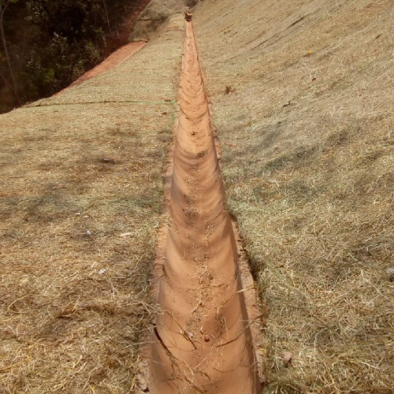

Canaleta de meia-cana na base de talude com biomanta

# 2. PRINCÍPIOS HIDRÁULICOS E SEDIMENTOLÓGICOS

## Hidráulica do escoamento vegetado

### Regime de escoamento

O escoamento em canaletas verdes opera predominantemente em **regime subcrítico** (Número de Froude $Fr < 1$), o que é desejável para evitar incisão erosiva. A vegetação densa aumenta a **resistência ao fluxo**, mantendo velocidades abaixo do limiar de erosão do solo.

**Número de Froude**

$$Fr = \frac{V}{\sqrt{g \cdot y_m}}$$

Onde $V$ é a velocidade média do fluxo (m/s), $g$ é a aceleração gravitacional (9,81 m/s²) e $y_m$ é a profundidade média do escoamento (m). Quando $Fr < 1$, o regime é subcrítico e a superfície livre é controlável.

### Tensão cisalhante no leito

$$\tau_0 = \gamma \cdot R_h \cdot S$$

Onde $\gamma$ é o peso específico da água (9.810 N/m³), $R_h$ é o raio hidráulico (m) e $S$ é a declividade longitudinal (m/m). A vegetação reduz $\tau_0$ ao diminuir $R_h$ (preenchimento parcial da seção pela massa vegetal) e ao dissipar energia pela rugosidade.

### Velocidades máximas admissíveis

| Tipo de revestimento | $V_{max}$ (m/s) | $\tau_{max}$ (N/m²) |
| --- | --- | --- |
| Grama baixa (< 5 cm) | 1,2 | 28 |
| Grama média (5–15 cm) | 1,5 | 47 |
| Grama densa (> 15 cm) | 1,8 | 96 |
| Capim-vetiver | 3,0–5,0 | 300–600 |
| Solo exposto (sem proteção) | 0,3–0,6 | 3–5 |
| Biomanta + grama jovem | 1,0 | 20 |

O **capim-vetiver** (*Chrysopogon zizanioides*) é excepcional para canaletas verdes em regiões tropicais, suportando velocidades de até 5 m/s graças ao seu sistema radicular fasciculado que penetra até 3 m de profundidade (Truong, Loch & Cook, 2008).

A velocidade máxima admissível no canal vegetado ($V_{max}$) é o **parâmetro de projeto mais restritivo**. Se $V > V_{max}$, deve-se aumentar a seção transversal, reduzir a declividade ou instalar dissipadores de energia (cordões vegetativos, enrocamento pontual).

## Mecanismo de filtração e infiltração

### Processos de remoção de sedimentos

A canaleta verde opera como um **biofiltro linear**, onde múltiplos processos atuam simultaneamente para remover sedimentos e poluentes do escoamento:

**1. Sedimentação gravitacional** ocorre pela redução de velocidade dentro do canal vegetado, permitindo que partículas com diâmetro $d > 62{,}5$ $\mu$m (areia e silte grosso) decantem por ação da gravidade segundo a lei de Stokes

$$v_s = \frac{(\rho_s - \rho_w) \cdot g \cdot d^2}{18 \cdot \mu}$$

onde $v_s$ é a velocidade de sedimentação (m/s), $\rho_s$ e $\rho_w$ são as densidades do sedimento e da água (kg/m³), $d$ é o diâmetro da partícula (m) e $\mu$ é a viscosidade dinâmica da água (Pa·s).

**2. Filtração mecânica** pela massa vegetal, em que colmos, folhas e raízes superficiais interceptam partículas em suspensão, funcionando como um filtro poroso tridimensional.

**3. Infiltração no perfil do solo** ao longo do comprimento do canal, promovendo recarga do lençol freático e amortecimento do hidrograma de cheia a jusante.

### Eficiência típica de remoção

| Parâmetro | Eficiência (%) | Mecanismo dominante |
| --- | --- | --- |
| Sedimentos totais (SST) | 60–90 | Sedimentação + filtração |
| Fósforo particulado | 40–70 | Sedimentação + adsorção |
| Nitrogênio total | 20–50 | Infiltração + absorção |
| Óleos e graxas | 50–80 | Filtração + biodegradação |
| Metais pesados | 30–60 | Adsorção + complexação |

### Diagrama conceitual

```
flowchart LR
    A["Escoamento<br>com sedimentos"] --> B["Entrada<br>da canaleta"]
    B --> C["Zona de<br>sedimentação"]
    C --> D["Zona de<br>filtração vegetal"]
    D --> E["Zona de<br>infiltração"]
    E --> F["Saída<br>com água limpa"]
    C --> G["Depósito de<br>sedimentos grosseiros"]
    D --> H["Retenção de<br>finos + nutrientes"]
    E --> I["Recarga do<br>lençol freático"]
    style B fill:#2135A6,color:#fff
    style C fill:#586BA6,color:#2135A6
    style D fill:#2E7D32,color:#fff
    style E fill:#8B4513,color:#fff
    style F fill:#4FC3F7,color:#000
```

A eficiência de remoção aumenta com o **comprimento do canal** (maior tempo de residência), a **densidade da vegetação** (maior área de interceptação) e a **permeabilidade do solo de fundação** (maior taxa de infiltração).

# 3. SEÇÕES TRANSVERSAIS E MATERIAIS

## Geometria da seção trapezoidal

### Parâmetros geométricos

A seção trapezoidal é definida pelos seguintes parâmetros:

**Área da seção transversal (A)**

$$A = \left(\frac{B + b}{2}\right) \cdot h = (b + Z \cdot h) \cdot h$$

**Perímetro molhado (P)**

$$P = b + 2h\sqrt{1 + Z^2}$$

**Raio hidráulico ($R_h$)**

$$R_h = \frac{A}{P}$$

**Largura superficial (T)**

$$T = b + 2 \cdot Z \cdot h$$

Onde $b$ é a base menor (m), $B$ é a base maior (m), $h$ é a profundidade do escoamento (m), $Z$ é a inclinação do talude ($Z = Y/h$, onde $Y$ é o afastamento horizontal) e $R_h$ é o raio hidráulico (m).

Para canaletas verdes, recomenda-se $Z \geq 3$ (talude 3H:1V ou mais suave), permitindo **mecanização da poda**, **acesso para manutenção** e **estabilidade geotécnica** sem revestimento estrutural.

### Dimensões típicas de projeto

| Parâmetro | Faixa recomendada |
| --- | --- |
| Base menor ($b$) | 0,30 – 2,00 m |
| Profundidade máxima ($h$) | 0,15 – 0,60 m |
| Talude ($Z$) | 3:1 a 6:1 |
| Borda livre | 0,10 – 0,15 m |
| Declividade longitudinal ($S$) | 0,5% – 5,0% |
| Comprimento máximo | 60 – 200 m |

**Borda livre (*freeboard*):** adicionar no mínimo 10–15 cm acima da lâmina d’água de projeto para acomodar variações no escoamento e evitar transbordamento.

$$h_{total} = h_{projeto} + h_{borda\,livre}$$

### Esquema da seção

```
      ┌─── T (largura superficial) ───┐
        │                            │
     ╱──┼────────── B ───────────────┼─╲   ← borda livre
    ╱   │                            │  ╲
   ╱    │   ←── b (base menor) ──→   │   ╲  h
  ╱     │                            │    ╲
 ╱──────┼────────────────────────────┼────-╲
         Z:1              Z:1
```

## Materiais e vegetação de revestimento

### Espécies recomendadas para revestimento

| Espécie | Nome popular | Características |
| --- | --- | --- |
| *Chrysopogon zizanioides* | Capim-vetiver | Raiz profunda (3 m), $V_{max}$ até 5 m/s |
| *Paspalum notatum* | Grama-batatais | Rizomatosa, rustica, cobertura densa |
| *Cynodon dactylon* | Grama-bermuda | Crescimento rápido, tolera tráfego |
| *Axonopus compressus* | Grama São Carlos | Adaptada a solos úmidos e sombreados |
| *Brachiaria decumbens* | Braquiária | Alta agressividade, rápido recobrimento |
| *Arachis pintoi* | Amendoim-forrageiro | Leguminosa, fixa N₂, cobertura rasteira |

A escolha da espécie depende do **regime hidráulico de projeto** (velocidade e tensão cisalhante esperadas), da **disponibilidade regional** de sementes ou mudas e da **manutenção disponível** (frequência de poda).

### Biomanta antierosiva na fase de estabelecimento

Na fase de estabelecimento (0–6 meses), a vegetação jovem **não confere proteção suficiente** ao solo. A instalação de **biomanta antierosiva** é essencial para proteger o canal durante esta fase.

| Tipo de biomanta | Material | Durabilidade |
| --- | --- | --- |
| BM1 (leve) | Palha + malha de juta | 6–12 meses |
| BM2 (média) | Fibra de coco + PP | 12–24 meses |
| BM3 (pesada) | Fibra de coco dupla | 24–36 meses |
| Permanente | PP/PET + fibra sintética | > 5 anos |

**Protocolo de instalação da biomanta:** desenrolar no sentido do fluxo (topo → base), fixar com grampos em U (espaçamento 0,5–1,0 m), sobrepor 15 cm nas emendas laterais e 20 cm nas emendas longitudinais. Grampos devem ser cravados no mínimo a 15 cm de profundidade.

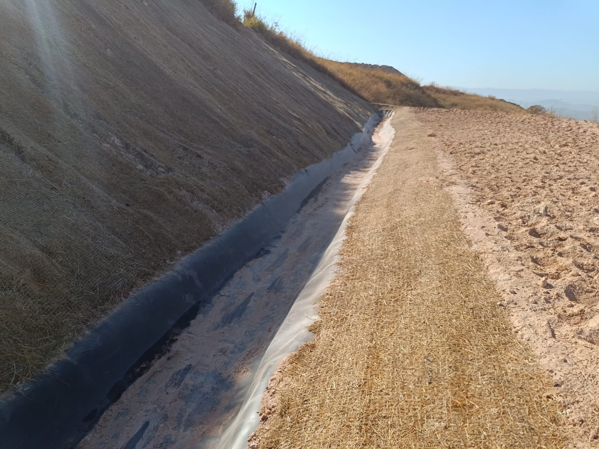

Canaleta verde com biomanta e hidrossemeadura

# 4. DIMENSIONAMENTO HIDRÁULICO (MANNING)

## Equação de Manning

### Formulação

A vazão em regime permanente e uniforme é estimada pela **equação de Manning**:

$$Q = \frac{1}{n} \cdot A \cdot R_h^{2/3} \cdot S^{1/2}$$

Onde:

- $Q$ = vazão de projeto (m³/s)
- $n$ = coeficiente de rugosidade de Manning (adimensional)
- $A$ = área da seção transversal (m²)
- $R_h$ = raio hidráulico (m)
- $S$ = declividade longitudinal do canal (m/m)

A **velocidade média** correspondente é:

$$V = \frac{R_h^{2/3} \cdot S^{1/2}}{n}$$

O parâmetro $n$ é a variável mais importante no projeto de canaletas verdes. Para vegetação densa e alta, utilizar $n = 0{,}040$ – $0{,}150$. A rugosidade **diminui** com o aumento da profundidade do fluxo (vegetação submersa se dobra, oferecendo menor resistência).

### Coeficientes de Manning para canais vegetados

| Condição de revestimento | $n$ (mínimo) | $n$ (normal) | $n$ (máximo) |
| --- | --- | --- | --- |
| Grama curta, ceifada (< 5 cm) | 0,025 | 0,030 | 0,035 |
| Grama média (5–15 cm) | 0,030 | 0,040 | 0,050 |
| Grama densa alta (> 15 cm) | 0,040 | 0,060 | 0,100 |
| Capim-vetiver (estande jovem) | 0,035 | 0,050 | 0,070 |
| Capim-vetiver (estande maduro) | 0,060 | 0,100 | 0,150 |
| Biomanta + grama em formação | 0,030 | 0,045 | 0,060 |
| Solo exposto (sem proteção) | 0,016 | 0,020 | 0,025 |

**Variação de $n$ com a submersão:** quando a lâmina d’água ultrapassa a altura da vegetação, os colmos se dobram (*bending effect*), reduzindo $n$. Para projeto simplificado, adota-se $n$ para a **condição de vegetação estabelecida** (conservador). Para projetos avançados, utilizar abordagens como a de Kouwen & Unny (1973) ou Temple (1987), que correlacionam $n$ com a rigidez vegetal e a profundidade do fluxo.

## Exemplo de dimensionamento

### Dados do problema

**Cenário:** Projetar uma canaleta verde trapezoidal para receber a descarga de 6 terraços em gradiente numa área agrícola de 4,5 ha.

**Dados disponíveis:**

### 1° Passo — Vazão de projeto (Método Racional)

$$Q = \frac{C \cdot I \cdot A}{360}$$

$$Q = \frac{0{,}55 \times 180 \times 4{,}5}{360} = 1{,}24 \text{ m³/s}$$

### 2° Passo — Área mínima da seção

A partir da restrição de velocidade:

$$A_{min} = \frac{Q}{V_{max}} = \frac{1{,}24}{1{,}5} = 0{,}83 \text{ m²}$$

### 3° Passo — Dimensões da seção

Adotando $h = 0{,}40$ m e resolvendo para $b$:

$$A = (b + Z \cdot h) \cdot h$$

$$0{,}83 = (b + 3 \times 0{,}40) \times 0{,}40$$

$$b = \frac{0{,}83}{0{,}40} - 1{,}20 = 0{,}88 \text{ m}$$

Adotar $b = 0{,}90$ m.

### Verificação da área efetiva

$$A = (0{,}90 + 1{,}20) \times 0{,}40 = 0{,}84 \text{ m²}$$

$$B = b + 2 \cdot Z \cdot h = 0{,}90 + 2{,}40 = 3{,}30 \text{ m}$$

## Exemplo de dimensionamento (continuação)

### 4° Passo — Raio hidráulico

**Perímetro molhado:**

$$P = b + 2h\sqrt{1 + Z^2} = 0{,}90 + 2(0{,}40)\sqrt{1 + 9}$$

$$P = 0{,}90 + 0{,}80 \times 3{,}162 = 3{,}43 \text{ m}$$

**Raio hidráulico:**

$$R_h = \frac{A}{P} = \frac{0{,}84}{3{,}43} = 0{,}245 \text{ m}$$

### 5° Passo — Velocidade real (Manning)

$$V = \frac{R_h^{2/3} \cdot S^{1/2}}{n} = \frac{(0{,}245)^{2/3} \cdot (0{,}03)^{1/2}}{0{,}060}$$

Calculando:

- $(0{,}245)^{2/3} = 0{,}391$
- $(0{,}03)^{1/2} = 0{,}1732$

$$V = \frac{0{,}391 \times 0{,}1732}{0{,}060} = 1{,}13 \text{ m/s}$$

Como $V = 1{,}13$ m/s $< V_{max} = 1{,}5$ m/s ✓

A velocidade está dentro do limite admissível para grama densa. A seção está segura.

### 6° Passo — Verificação da vazão transportada

$$Q_{calc} = V \times A = 1{,}13 \times 0{,}84 = 0{,}95 \text{ m³/s}$$

**Atenção:** $Q_{calc} = 0{,}95$ m³/s $< Q_{projeto} = 1{,}24$ m³/s ❌

A seção não é suficiente! Necessário aumentar as dimensões.

### Ajuste: aumentar profundidade para $h = 0{,}50$ m

$$A = (0{,}90 + 3 \times 0{,}50) \times 0{,}50 = (0{,}90 + 1{,}50) \times 0{,}50 = 1{,}20 \text{ m²}$$

$$P = 0{,}90 + 2(0{,}50)\sqrt{10} = 0{,}90 + 3{,}162 = 4{,}06 \text{ m}$$

$$R_h = 1{,}20 / 4{,}06 = 0{,}296 \text{ m}$$

$$V = \frac{(0{,}296)^{2/3} \times 0{,}1732}{0{,}060} = \frac{0{,}446 \times 0{,}1732}{0{,}060} = 1{,}29 \text{ m/s}$$

$$Q_{calc} = 1{,}29 \times 1{,}20 = 1{,}55 \text{ m³/s} > 1{,}24 \text{ m³/s ✓}$$

**Seção final adotada:** $b = 0{,}90$ m, $h = 0{,}50$ m, $Z = 3$, $B = 3{,}90$ m. Com borda livre de 0,15 m, a profundidade escavada total é $h_t = 0{,}65$ m.

## Número de Froude e verificação do regime

### Verificação do regime de escoamento

Para a seção final ($h = 0{,}50$ m, $V = 1{,}29$ m/s):

**Profundidade hidráulica média ($D_m$)**

$$D_m = \frac{A}{T} = \frac{1{,}20}{3{,}90} = 0{,}308 \text{ m}$$

**Número de Froude**

$$Fr = \frac{V}{\sqrt{g \cdot D_m}} = \frac{1{,}29}{\sqrt{9{,}81 \times 0{,}308}}$$

$$Fr = \frac{1{,}29}{1{,}738} = 0{,}74$$

$Fr = 0{,}74 < 1{,}0$ → **Regime subcrítico** ✓

O escoamento é subcrítico, condição desejável para canaletas verdes, que garante controle do fluxo e favorece a deposição de sedimentos.

### Quadro-resumo do dimensionamento

| Parâmetro | Valor |
| --- | --- |
| Vazão de projeto ($Q$) | 1,24 m³/s |
| Base menor ($b$) | 0,90 m |
| Profundidade do escoamento ($h$) | 0,50 m |
| Borda livre | 0,15 m |
| Profundidade total escavada | 0,65 m |
| Talude ($Z$) | 3:1 |
| Base maior ($B$) | 3,90 m |
| Área da seção ($A$) | 1,20 m² |
| Perímetro molhado ($P$) | 4,06 m |
| Raio hidráulico ($R_h$) | 0,296 m |
| Velocidade ($V$) | 1,29 m/s |
| Vazão transportada ($Q_{calc}$) | 1,55 m³/s |
| Número de Froude ($Fr$) | 0,74 |
| Regime de escoamento | Subcrítico |

A folga hidráulica ($Q_{calc}/Q_{projeto} = 1{,}25$) garante um fator de segurança de 25% acima da vazão de projeto, adequado para incertezas no coeficiente de rugosidade e variações locais da declividade.

# 5. PROJETO E IMPLANTAÇÃO EM CAMPO

## Etapas de implantação

### Sequência executiva

O processo de implantação segue uma sequência rigorosa para garantir a funcionalidade hidráulica e a estabilidade do revestimento vegetal:

**Etapa 1 — Levantamento planialtimétrico** da área de implantação com drone (GNSS-RTK) ou estação total, gerando perfil longitudinal e seções transversais a cada 10–20 m.

**Etapa 2 — Locação e escavação** do canal conforme dimensionamento (retroescavadeira ou miniescavadeira). Controlar cota de fundo com nível de mangueira ou nível laser. Compactar levemente o leito (90% Proctor Normal) para evitar recalques.

**Etapa 3 — Regularização e perfilamento** dos taludes com talude mínimo de 3H:1V. Remover torrões e pedras soltas. A superfície deve estar lisa para receber a biomanta.

**Etapa 4 — Instalação da biomanta** antierosiva de coco (BM2 ou BM3, conforme tensão cisalhante de projeto) com grampos em U a cada 0,50–1,00 m, sobreposições longitudinais de 20 cm e laterais de 15 cm.

**Etapa 5 — Hidrossemeadura** com mistura de sementes de gramíneas e leguminosas, fertilizante, mulch vegetal e ligante adesivo, aplicada diretamente sobre a biomanta. Taxa de aplicação típica de 30–50 g/m² de sementes.

**Etapa 6 — Irrigação inicial** (se necessário) nos primeiros 15–30 dias para garantir germinação, especialmente em períodos secos.

**Etapa 7 — Inspeção pós-implantação** após o primeiro evento de chuva significativo, verificar integridade da biomanta, germinação e estabilidade dos taludes.

```
flowchart TD
    A["1. Levantamento<br>planialtimétrico"] --> B["2. Locação e<br>escavação"]
    B --> C["3. Regularização<br>dos taludes"]
    C --> D["4. Instalação<br>da biomanta"]
    D --> E["5. Hidrossemeadura"]
    E --> F["6. Irrigação<br>inicial"]
    F --> G["7. Inspeção pós-<br>primeiro evento"]

    style A fill:#2135A6,color:#fff
    style B fill:#2135A6,color:#fff
    style C fill:#2135A6,color:#fff
    style D fill:#2E7D32,color:#fff
    style E fill:#2E7D32,color:#fff
    style F fill:#586BA6,color:#2135A6
    style G fill:#27368C,color:#fff
```

## Detalhes construtivos especiais

### Dissipadores de energia internos

Em canaletas com declividade superior a 3%, recomenda-se a instalação de **dissipadores de energia** ao longo do canal para evitar aceleração excessiva do fluxo:

| Tipo de dissipador | Declividade recomendada | Espaçamento |
| --- | --- | --- |
| Cordão de vetiver | 3–5% | 5–10 m |
| Enrocamento pontual | 5–8% | 3–5 m |
| Degrau revestido | > 8% | 2–3 m |
| Paliçada interna (bambu) | > 5% | 3–8 m |

Os **cordões de vetiver** (*Chrysopogon zizanioides*) plantados transversalmente ao fluxo a intervalos regulares funcionam como micro-barragens permeáveis que reduzem a velocidade sem impedir a passagem da água, combinando **dissipação mecânica** (resistência dos colmos) com **estabilização biotécnica** (ancoragem radicular).

### Transição entrada/saída

A **entrada** da canaleta verde deve possuir uma zona de transição (enrocamento ou concreto ciclópico num trecho curto de 1–2 m) para dissipar a energia cinética do fluxo de chegada e evitar incisão no início do canal vegetado.

A **saída** deve ser protegida por um **dissipador de energia** (bacia de amortecimento, enrocamento, ou talude revestido) para evitar erosão remontante no ponto de descarga.

### Espaçamento de cordões internos

O espaçamento entre cordões de vetiver pode ser estimado pela relação geométrica:

$$L_{cord} = \frac{h_{cord}}{\tan(\alpha)}$$

Onde $h_{cord}$ é a altura do cordão de vetiver (0,20–0,40 m) e $\alpha$ é a declividade do canal. Para $\alpha = 3\%$ e $h_{cord} = 0{,}30$ m:

$$L_{cord} = \frac{0{,}30}{0{,}03} = 10{,}0 \text{ m}$$

O princípio é o mesmo das paliçadas em ravinas, a base do cordão a montante deve ficar em nível com o topo do cordão a jusante, assegurando deposição uniforme entre as barreiras.

# 6. COMBINAÇÃO COM HIDROSSEMEADURA E BIOMANTA

## Sistema integrado de bioengenharia

### O tripé da canaleta verde

A canaleta verde atinge máxima eficiência quando combinada em um sistema integrado com **biomanta antierosiva** e **hidrossemeadura**, formando um tripé de proteção:

**Biomanta** fornece proteção mecânica imediata ao solo exposto durante a fase de estabelecimento vegetal. Reduz a tensão cisalhante efetiva no leito ($\tau_{efetivo} = \tau_0 - \tau_{biomanta}$), absorvendo impacto de gotas de chuva (*splash erosion*) e retendo umidade para germinação.

**Hidrossemeadura** permite a aplicação mecanizada e uniforme de uma mistura de sementes, fertilizante, mulch e ligante sobre a biomanta. A pulverização pressurizada garante contato íntimo semente–substrato e distribuição homogênea, com taxas de germinação de 70–90% em condições ótimas.

**Vegetação estabelecida** assume progressivamente a proteção do canal, substituindo a biomanta biodegradável que se degrada em 6–36 meses. O sistema radicular penetra no solo, aumentando a coesão efetiva ($c' = c'_{solo} + \Delta c'_{raiz}$), e a parte aérea mantém a rugosidade hidráulica elevada.

### Cronograma de transição funcional

```
gantt
    title Fases de proteção da canaleta verde
    dateFormat YYYY-MM
    axisFormat %b/%Y
    section Biomanta
        Proteção mecânica plena   :active, b1, 2026-01, 12M
        Degradação progressiva    :b2, after b1, 12M
    section Hidrossemeadura
        Aplicação + germinação    :h1, 2026-01, 2M
        Crescimento vegetativo    :h2, after h1, 4M
    section Vegetação
        Cobertura parcial (< 80%) :v1, 2026-03, 6M
        Cobertura plena (> 80%)   :crit, v2, after v1, 18M
    section Proteção total
        Biomanta + vegetal jovem  :p1, 2026-01, 6M
        Vegetal maduro autossuficiente :crit, p2, after p1, 18M
```

**Ponto de cruzamento:** entre 6 e 12 meses, a cobertura vegetal atinge 80%, momento em que a proteção do canal passa a ser **dominada pela vegetação viva** e a biomanta pode iniciar sua degradação natural sem comprometer a integridade do sistema.

## Composição da mistura de hidrossemeadura

### Mistura-tipo para canaletas verdes (clima tropical)

| Componente | Quantidade (por m²) | Função |
| --- | --- | --- |
| *Brachiaria decumbens* | 8–10 g | Cobertura rápida, rusticidade |
| *Paspalum notatum* | 5–8 g | Cobertura densa, persistência |
| *Arachis pintoi* | 3–5 g | Fixação de N₂, cobertura rasteira |
| *Chrysopogon zizanioides* | 2–3 g (ou mudas) | Ancoragem profunda, dissipação |
| Fertilizante NPK (10-10-10) | 30–50 g | Nutrição inicial |
| Calcário dolomítico | 50–100 g | Correção de pH |
| Mulch de celulose | 100–200 g | Retenção de umidade |
| Ligante adesivo (tackifier) | 5–10 g | Fixação ao substrato |

O **capim-vetiver** é preferencialmente implantado por **mudas** (estolões), espaçadas a cada 15–20 cm nos cordões transversais, pois sua taxa de germinação por semente é baixa em condições de campo.

### Hidrossemeadura: princípios operacionais

A aplicação é realizada com **hidrossemeador** (tanque de 1.000–8.000 L montado em caminhão ou reboque), que mistura água + sementes + fertilizante + mulch + ligante e projeta a mistura a pressão (200–400 kPa) sobre a superfície da biomanta.

**Vantagens** da hidrossemeadura em canaletas:

- Aplicação uniforme em taludes inclinados
- Contato semente–substrato otimizado
- Velocidade de cobertura (até 2.000 m²/h)
- Mistura nutricional completa em uma operação
- Aderência à biomanta pelo ligante adesivo

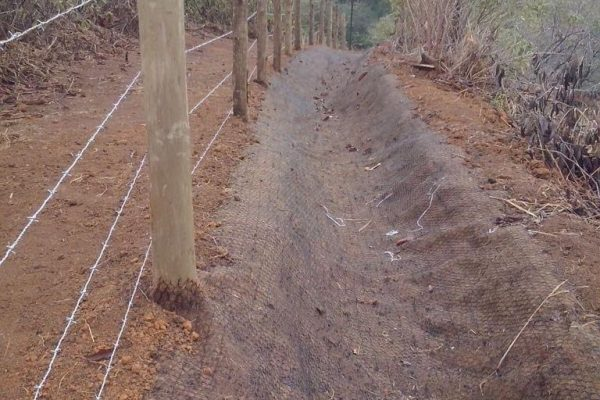

Canaleta verde após hidrossemeadura sobre biomanta

# 7. MONITORAMENTO E MANUTENÇÃO

## Protocolo de monitoramento

### Parâmetros de monitoramento

O monitoramento da canaleta verde deve ser realizado em três dimensões: **hidráulica**, **vegetacional** e **geomorfológica**.

**Monitoramento hidráulico** consiste na medição de vazão na entrada e na saída do canal (calha Parshall, vertedouro triangular ou método volumétrico) para avaliar a **taxa de infiltração efetiva** ao longo do percurso. A diferença $\Delta Q = Q_{entrada} - Q_{saída}$ representa o volume infiltrado e o retido por deposição.

**Monitoramento vegetacional** envolve a estimativa periódica (mensal nos primeiros 6 meses, trimestral após) da **cobertura vegetal (%)** por quadrante (1 m²), da **altura da vegetação** e da **diversidade funcional** (gramíneas vs. leguminosas vs. invasoras).

**Monitoramento geomorfológico** utiliza o **método dos pinos** (pinos de ferro de 30 cm cravados a 10 cm, espaçados a cada 5 m) para quantificar erosão residual ou deposição no leito e taludes, além de levantamentos fotogramétricos periódicos com drone (MDT diferencial).

### Indicadores de desempenho

| Indicador | Meta | Frequência |
| --- | --- | --- |
| Cobertura vegetal | > 80% em 6 meses | Mensal/trimestral |
| Velocidade de fluxo | < $V_{max}$ adotada | Eventos de chuva |
| Erosão no leito (pinos) | < 1 cm/ano | Mensal |
| Integridade da biomanta | Sem rasgos ou deslocamentos | Após chuvas |
| Sedimentos retidos | Medição por pinos/batimetria | Semestral |
| Taxa de infiltração | > 50% do escoamento | Semestral |

**Critério de sucesso:** a canaleta verde é considerada **operacionalmente eficiente** quando atinge cobertura vegetal > 80%, mantém velocidade de fluxo abaixo do limite admissível e apresenta erosão líquida no leito inferior a 1 cm por ano.

Após o estabelecimento pleno da vegetação (12–24 meses), a frequência de monitoramento pode ser **reduzida** para semestral, focando em manutenção preventiva (poda, replantio de falhas, limpeza de sedimentos na entrada).

## Manutenção periódica

### Cronograma de manutenção

| Atividade | Frequência | Período |
| --- | --- | --- |
| Poda da vegetação (manter 10–20 cm) | Trimestral | Ano todo |
| Replantio de falhas (< 80% cobertura) | Conforme necessidade | Estação chuvosa |
| Limpeza de sedimentos na entrada | Semestral | Pós-chuvas |
| Inspeção da biomanta | Mensal (1º ano) | Estação chuvosa |
| Fertilização de manutenção | Anual | Início das chuvas |
| Controle de invasoras | Trimestral | Ano todo |
| Reparo de erosão localizada | Conforme necessidade | Pós-eventos |

A **poda regular** é essencial: a vegetação excessivamente alta (> 30 cm) pode tombar e formar uma **manta de material morto** (*thatch*) que reduz a infiltração e cria caminhos preferenciais de fluxo. Manter entre 10 e 20 cm é o equilíbrio ótimo entre rugosidade hidráulica e permeabilidade do leito.

### Modos de falha e ações corretivas

| Modo de falha | Causa provável | Ação corretiva |
| --- | --- | --- |
| Incisão no leito | $V > V_{max}$, vegetação insuficiente | Instalar dissipadores, replantar |
| Erosão lateral (taludes) | Talude íngreme, falta de cobertura | Reperfilar para $Z \geq 3$, biomanta |
| Bypass (transbordamento) | Seção subdimensionada, obstrução | Desobstruir, ampliar seção |
| Assoreamento excessivo | Fonte de sedimento a montante | Controlar nascente, limpar |
| Mortalidade vegetal | Seca, herbicida, sombreamento | Replantio, irrigação emergencial |
| Piping (erosão interna) | Solo dispersivo, compactação deficiente | Recompactar, drenar, colocar filtro |

Em solos com **alta dispersibilidade** (presença de sódio trocável, como Neossolos ou Planossolos com horizonte B solódico), o risco de **piping** (erosão interna por tubulação) é elevado. Nesses casos, instalar uma **camada de filtro geotêxtil** sob a biomanta e garantir compactação adequada (95% Proctor Normal) do leito e taludes.

# 8. SÍNTESE E ATIVIDADE

## Resumo dos pontos-chave

### O que aprendemos?

- 1 A canaleta verde é um canal vegetado raso e largo que substitui canais de concreto, promovendo condução controlada, infiltração e filtração de sedimentos
- 2 O dimensionamento segue a equação de Manning, com o coeficiente de rugosidade $n$ como variável-chave (0,030–0,150 para vegetação)
- 3 A velocidade máxima admissível ($V_{max}$) é o parâmetro de projeto mais restritivo e depende do tipo de revestimento vegetal
- 4 O sistema integrado biomanta + hidrossemeadura + vegetação permanente garante proteção desde a implantação até a maturidade
- 5 O capim-vetiver (*C. zizanioides*) é a espécie referência em regiões tropicais, suportando velocidades de até 5 m/s
- 6 O monitoramento hidráulico, vegetacional e geomorfológico é essencial para verificar a eficiência e detectar falhas precocemente
- 7 A manutenção periódica (poda, replantio, limpeza) garante a longevidade do sistema vegetado

### Fluxograma de projeto completo

```
flowchart TD
    A["Levantamento<br>topográfico"] --> B["Cálculo da vazão<br>(Método Racional)"]
    B --> C["Dimensionamento<br>(Manning)"]
    C --> D{"V ≤ V_max?"}
    D -->|Sim| E["Definir seção<br>e borda livre"]
    D -->|Não| F["Aumentar seção<br>ou dissipadores"]
    F --> C
    E --> G["Verificar Fr < 1<br>(subcrítico)"]
    G --> H["Especificar biomanta<br>e hidrossemeadura"]
    H --> I["Escavar e<br>revestir"]
    I --> J["Implantar e<br>monitorar"]

    style A fill:#2135A6,color:#fff
    style C fill:#2135A6,color:#fff
    style D fill:#586BA6,color:#2135A6
    style E fill:#2E7D32,color:#fff
    style G fill:#2135A6,color:#fff
    style J fill:#27368C,color:#fff
```

## Atividade proposta

### Exercício em grupo

**Cenário:** Uma empresa de mineração contratou vocês para projetar uma canaleta verde para conduzir o escoamento pluvial ao longo da base de um talude de corte com as seguintes características:

- Comprimento do talude: 120 m
- Área de contribuição: 2,8 ha
- Coeficiente de enxurrada: $C = 0{,}65$
- Intensidade de chuva (TR = 25 anos): $I = 210$ mm/h
- Declividade da canaleta: $S = 2{,}5\%$
- Solo de fundação: Latossolo Vermelho-Amarelo
- Revestimento previsto: *Chrysopogon zizanioides* (vetiver)

**Entregar:**

1. Vazão de projeto (Método Racional)
2. Dimensionamento da seção trapezoidal ($b$, $h$, $Z$, $B$)
3. Verificação de velocidade e regime (Manning + Froude)
4. Especificação da biomanta e mistura de hidrossemeadura
5. Protocolo de monitoramento (parâmetros e frequência)
6. Cronograma de manutenção para 2 anos

### Critérios de avaliação

| Critério | Peso |
| --- | --- |
| Dimensionamento hidráulico correto | 30% |
| Verificação de velocidade e regime | 20% |
| Especificação de materiais (biomanta + hidrossemeadura) | 20% |
| Protocolo de monitoramento | 15% |
| Apresentação e coerência técnica | 15% |

### Referências sugeridas

- Truong, Loch & Cook (2008), *Vetiver System Applications*
- Morgan (2005), *Soil Erosion and Conservation*
- USDA-NRCS (2007), *Grassed Waterway Design*
- Menezes & Sampaio (2021), Bioengenharia de Solos no Nordeste
- Florineth (2004), *Pflanzen statt Beton*
- Temple (1987), *Closure of “Stability Design of Grass-Lined Open Channels”*
- Kouwen & Unny (1973), *Flexible roughness in open channels*
- GreenBrasil Bioengenharia — greenbrasil.eco.br

### Formulário resumido

$$Q = \frac{C \cdot I \cdot A}{360} \quad\quad V = \frac{R_h^{2/3} \cdot S^{1/2}}{n} \quad\quad Fr = \frac{V}{\sqrt{g \cdot D_m}}$$

Obrigado!

**Prof. Luiz Diego Vidal Santos**

Universidade Estadual de Feira de Santana (UEFS)

ldvsantos@uefs.br